# Lab4_answers

sbsambado

1/25/2021

# Answers for Lab 4

*Notes*

ALL HOMEWORK SHOULD BE SUBMITTED AS A KNITTED HOMEWORK FILE (.PDF or .HTML)

- -2.0 points if HW not in right format (-2 points)
- -.25 point if code is not annotated
- -.25 point if answers are not in complete sentences
- -.25 point if code does not seem adequate to answer question

**Question 1**

Use a **paired t-test** to answer the following question: *Does writing the phase “The search for truth” take a different amount of time with your weak v. dominant hand?* Specifically, include the following information in your homework, along will all necessary code:

1. Clearly *state* your null and alternative hypotheses of your paired t-test.

```r
# null hypothesis: mean of dominant = mean of week (there is no difference btween the time it takes to write)

# alternative hypothesis: mean of dominant != mean of weak (There is a difference between the time it takes to write ")
```

2. Visualize your data in a meaningful way.

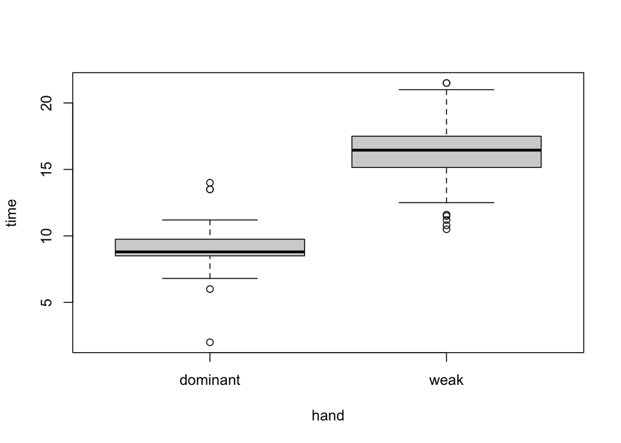

```r
# make new column for differences

# Option 1
dominant <- subset(dexterity, hand=="dominant")
weak  <- subset(dexterity, hand=="weak")
diff <- dominant$time - weak$time

# Option 2
weak <- dexterity$time[dexterity$hand=="weak"] #create new data section for each hand
dominant <- dexterity$time[dexterity$hand=="dominant"] #create new data section for each hand
difference <- weak - dominant

# Make a boxplot or histogram the dominant and weak hand
boxplot(time ~ hand, data = dexterity)
```

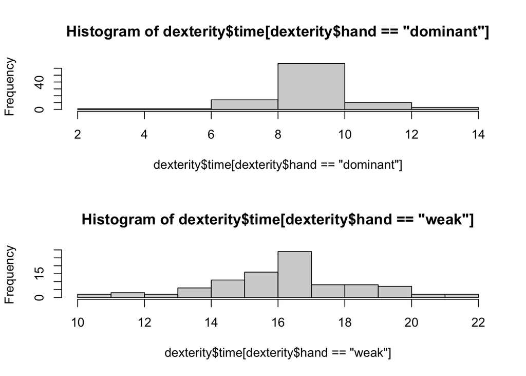

```r
par(mfrow = c(2,1))
hist(dexterity$time[dexterity$hand == "dominant"])
hist(dexterity$time[dexterity$hand == "weak"])
```

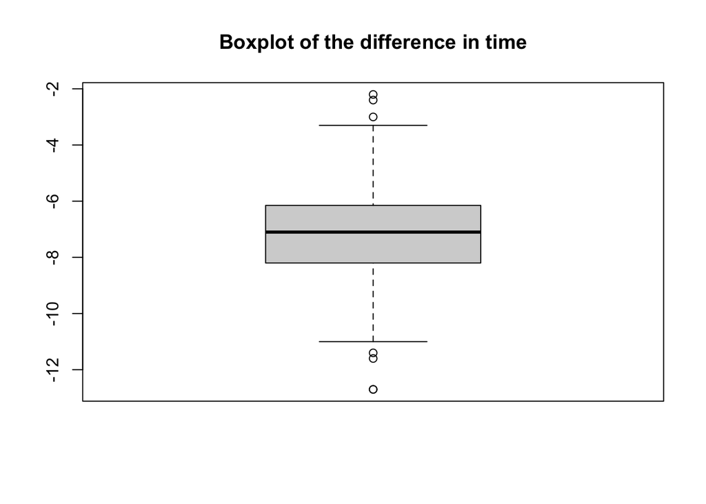

```r
par(mfrow = c(1,1))

# Students can also plot the differences
boxplot(diff, main = "Boxplot of the difference in time")
```

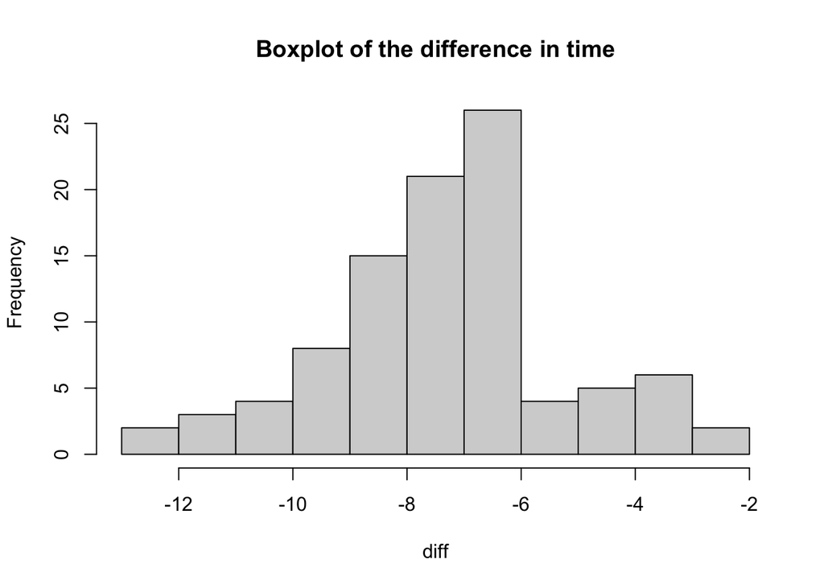

```r
hist(diff, main = "Boxplot of the difference in time")
```

3. Determine if the data are normally distributed and, if not, whether you think the Central Limit Theorem will allow you to use a statistical test that assumes normality. Include both a qqPlot and a Shapiro-Wilk statistic.
   - Hint: to do this you will need to create a new variable that is the difference between each person’s weak hand and dominant hand and test whether this new variable is normally distributed using a qqPlot and a Shapiro-Wilk test.

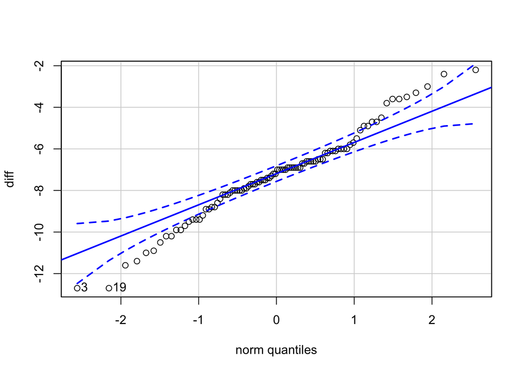

```
## [1]  3 19
```

```r
# make new column for differences

# Option 1
dominant <- subset(dexterity, hand=="dominant")
weak  <- subset(dexterity, hand=="weak")
diff <- dominant$time - weak$time

# Option 2
weak <- dexterity$time[dexterity$hand=="weak"] #create new data section for each hand
dominant <- dexterity$time[dexterity$hand=="dominant"] #create new data section for each hand
difference <- weak - dominant

# check the normality of the differences
# First, with qqPlot
qqPlot(diff) # looks somewhat normal distribution
```

```r
# Second, with shapiro.test
shapiro.test(diff)
```

```
##
##  Shapiro-Wilk normality test
##
## data:  diff
## W = 0.97991, p-value = 0.1481
```

```r
# p-value = 0.1481
# 0.1481 > 0.05
# we fail to reject the null hypothesis
# data are normally distributed
```

4. Regardless of whether or not you think the assumptions of the t-test hold, *report* the 95% confidence interval for the paired t-test. Use the 95% CI to reject or fail to reject your null hypothesis. Be specific as to why you do one or the other and *state* your conclusions about the dominant v. weak hand dexterity.

```r
# Null hypothesis: mean of the differences = 0
t.test(dominant, weak, paired = TRUE)
```

```
##
##  Paired t-test
##
## data:  dominant and weak
## t = -34.218, df = 95, p-value < 2.2e-16
## alternative hypothesis: true difference in means is not equal to 0
## 95 percent confidence interval:
##  -7.700379 -6.855871
## sample estimates:
## mean of the differences
##               -7.278125
```

```r
# p value < 2.2e-16
# t = -34.218
# 95CI: -7.700379 - 6.855871
  # CI does not contain 0 we can reject our null
  # We can reject our null hypothesis at alpha = 0.05
    # Mean of the differences is not 0, meaning there is a significant difference between the mean time for hands writing "The search for truth"


# or one sample t-test on difference
t.test(diff, mu = 0)
```

```
##
##  One Sample t-test
##
## data:  diff
## t = -34.218, df = 95, p-value < 2.2e-16
## alternative hypothesis: true mean is not equal to 0
## 95 percent confidence interval:
##  -7.700379 -6.855871
## sample estimates:
## mean of x
## -7.278125
```

```r
# p value < 2.2e-16
# mean is not equal to 0, there is a significant difference between the mean time for writing "The search for truth"
```

**Question 2: Natural selection in birds**